# Fixed or Random — Which Model Fits?

- Show All Code
- Hide All Code
- View Source

From Fixed Effects to Random Effects, and How to Choose

Author

Dr Clemens Jarnach

Published

February 1, 2027

**Load packages**

```r
library(tidyverse)
library(plm)
library(knitr)
library(RColorBrewer)

pal_farms <- brewer.pal(5, "Set2")
```

## Recap — What We Learned in Exercise 1

In the first exercise we tracked five farms over two years and found:

- **Pooled OLS** was badly biased — it confused high-quality farms with productive farms.
- **Fixed Effects (FE)** eliminated that bias by using *within-farm* variation only: holding each farm constant and asking “when this farm hired more workers, did it produce more?”
- The FE estimate ($\hat\beta_{\text{FE}} \approx 2.5$) was close to the true value; OLS was far above it.

**NoteThe FE trade-off**

FE is powerful because it controls for **all** time-invariant unobserved heterogeneity — soil quality, management culture, location — without ever measuring it. But that power comes at a cost:

> *FE can only use within-unit variation. Anything that does not change over time within a unit cannot be estimated.*

If you want to know whether **organic certification** (a fixed farm characteristic) affects productivity, FE cannot help — it has already “swept out” all between-farm differences.

This exercise asks: **is there an alternative that uses more of the data and can still estimate time-invariant effects?**

## Step 1 — Extending the Panel to Four Years

We now follow the same five farms across **four years** instead of two. Each farm changes its labour input modestly from year to year.

**Generate 4-year panel data**

```r
set.seed(42)
true_beta <- 2.5
farms     <- LETTERS[1:5]
years     <- paste0("Year ", 1:4)

# Unobserved soil quality — correlated with labour (same as Exercise 1)
# Farm A is best, E is worst; better farms hire more workers
quality_a <- c(75, 70, 63, 52, 35)

# Labour matrix: rows = farms, columns = years
# Better farms (A, B) expand labour over time; worse farms stay small
labour_mat <- matrix(
  c( 6,  7,  8, 10,   # Farm A
     5,  5,  6,  8,   # Farm B
     4,  5,  4,  6,   # Farm C
     3,  3,  4,  4,   # Farm D
     1,  2,  1,  2),  # Farm E
  nrow = 5, byrow = TRUE
)

# Output = quality + beta*labour + noise
# as.vector(labour_mat) goes column-by-column: all farms in Year 1, then Year 2, …
# matching rep(years, each=5) and rep(farms, times=4)
set.seed(42)
output_mat_a <- matrix(0, nrow = 5, ncol = 4)
for (t in 1:4) {
  output_mat_a[, t] <- quality_a + true_beta * labour_mat[, t] + rnorm(5, 0, 1.5)
}
output_mat_a <- round(output_mat_a)

df_panel <- tibble(
  Farm   = rep(farms, times = 4),
  Year   = rep(years, each  = 5),
  t      = rep(1:4,   each  = 5),
  Labour = as.vector(labour_mat),
  Output = as.vector(output_mat_a)
)
```

**Display panel**

```r
kable(
  df_panel |> select(Farm, Year, Labour, Output),
  col.names = c("Farm", "Year", "Labour (workers)", "Output (tonnes)"),
  align = "cccc",
  caption = "Table 1 — Extended panel: 5 farms × 4 years = 20 observations"
)
```

Table 1 — Extended panel: 5 farms × 4 years = 20 observations

| Farm | Year | Labour (workers) | Output (tonnes) |
| --- | --- | --- | --- |
| A | Year 1 | 6 | 92 |
| B | Year 1 | 5 | 82 |
| C | Year 1 | 4 | 74 |
| D | Year 1 | 3 | 60 |
| E | Year 1 | 1 | 38 |
| A | Year 2 | 7 | 92 |
| B | Year 2 | 5 | 85 |
| C | Year 2 | 5 | 75 |
| D | Year 2 | 3 | 63 |
| E | Year 2 | 2 | 40 |
| A | Year 3 | 8 | 97 |
| B | Year 3 | 6 | 88 |
| C | Year 3 | 4 | 71 |
| D | Year 3 | 4 | 62 |
| E | Year 3 | 1 | 37 |
| A | Year 4 | 10 | 101 |
| B | Year 4 | 8 | 90 |
| C | Year 4 | 6 | 74 |
| D | Year 4 | 4 | 58 |
| E | Year 4 | 2 | 42 |

**Plot panel trajectories**

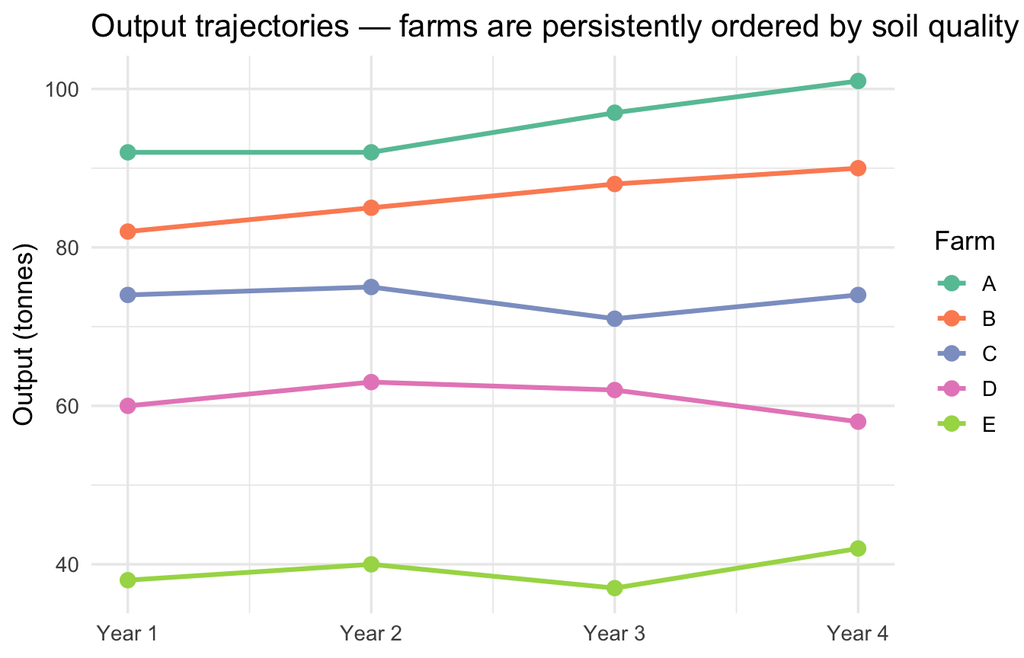

Figure 1 — Farm output trajectories over four years

```r
ggplot(df_panel, aes(x = t, y = Output, colour = Farm, group = Farm)) +
  geom_line(linewidth = 1.1) +
  geom_point(size = 3) +
  scale_x_continuous(breaks = 1:4, labels = years) +
  scale_colour_brewer(palette = "Set2") +
  labs(x = NULL, y = "Output (tonnes)",
       title = "Output trajectories — farms are persistently ordered by soil quality") +
  theme_minimal(base_size = 13)
```

**TipWhat do you notice about the ordering?**

Farm A always leads, Farm E always trails. This persistent ordering reflects **unobserved soil quality** ($\alpha_i$), which is fixed across time. FE controls for this perfectly — but by doing so it also discards all the *between-farm* information.

## Step 2 — Introducing the Random Effects Model

The **Random Effects (RE) model** offers a middle path. Instead of eliminating $\alpha_i$ by differencing it away, it treats $\alpha_i$ as a **random variable** drawn from a distribution:

$$y_{it} = \mu + \beta\, x_{it} + \underbrace{\alpha_i + u_{it}}_{\varepsilon_{it}}$$

where:

| Symbol | Meaning |
| --- | --- |
| $\mu$ | Grand intercept |
| $\beta$ | Effect of labour (what we want) |
| $\alpha_i$ | Farm-level random intercept (unobserved heterogeneity) |
| $u_{it}$ | Idiosyncratic noise |

The composite error $\varepsilon_{it} = \alpha_i + u_{it}$ has a **block structure**: observations from the same farm are correlated because they share $\alpha_i$. RE uses Generalised Least Squares (GLS) to exploit this structure, weighting within and between variation optimally.

**ImportantThe critical assumption**

RE requires:

$$\text{Cov}(\alpha_i,\, x_{it}) = 0$$

> *The unobserved farm-level characteristic must be **uncorrelated** with the predictor.*

If this fails — as it did in Exercise 1, where better farms (high $\alpha_i$) also hired more workers (high $x_{it}$) — RE inherits the same omitted-variable bias as OLS. FE, by contrast, is consistent regardless.

## Step 3 — Scenario A: When RE Fails (Correlated Heterogeneity)

This is our **original farm data** from Exercise 1, now extended to four years. Soil quality is strongly **correlated** with labour: better farms (high $\alpha_i$) consistently hire more workers.

**Fit OLS, FE, and RE on correlated data**

```r
pdata_a <- pdata.frame(df_panel, index = c("Farm", "Year"))

mod_ols_a <- lm(Output ~ Labour, data = df_panel)
mod_fe_a  <- plm(Output ~ Labour, data = pdata_a, model = "within")
mod_re_a  <- plm(Output ~ Labour, data = pdata_a, model = "random")

beta_ols_a <- round(coef(mod_ols_a)["Labour"], 3)
beta_fe_a  <- round(coef(mod_fe_a)["Labour"],  3)
beta_re_a  <- round(coef(mod_re_a)["Labour"],  3)
```

**Display comparison table**

```r
tibble(
  Estimator        = c("Pooled OLS", "Fixed Effects", "Random Effects"),
  `β̂ (Labour)`    = c(beta_ols_a, beta_fe_a, beta_re_a),
  `True β`         = true_beta,
  Bias             = c(round(beta_ols_a - true_beta, 3),
                       round(beta_fe_a  - true_beta, 3),
                       round(beta_re_a  - true_beta, 3)),
  `Variation used` = c("Between + within",
                       "Within only",
                       "Within + between (weighted)")
) |>
  kable(align = "lcccc",
        caption = "Table 2 — Scenario A: heterogeneity correlated with labour")
```

Table 2 — Scenario A: heterogeneity correlated with labour

| Estimator | β̂ (Labour) | True β | Bias | Variation used |
| --- | --- | --- | --- | --- |
| Pooled OLS | 7.925 | 2.5 | 5.425 | Between + within |
| Fixed Effects | 2.000 | 2.5 | -0.500 | Within only |
| Random Effects | 4.065 | 2.5 | 1.565 | Within + between (weighted) |

**Plot all three fits**

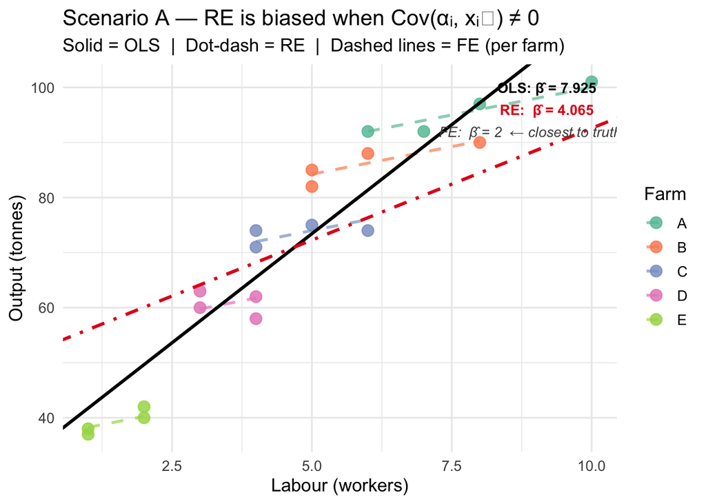

Figure 2 — Scenario A: OLS, FE, and RE fits on correlated data

```r
df_panel_a <- df_panel |>
  group_by(Farm) |>
  mutate(Farm_mean_L = mean(Labour), Farm_mean_O = mean(Output)) |>
  ungroup()

ggplot(df_panel_a, aes(x = Labour, y = Output, colour = Farm, group = Farm)) +
  # FE: parallel within-slope lines, one per farm
  geom_line(aes(y = Farm_mean_O + beta_fe_a * (Labour - Farm_mean_L)),
            linewidth = 1, linetype = "dashed", alpha = 0.7) +
  geom_point(size = 3.5, alpha = 0.85) +
  # Pooled OLS
  geom_abline(intercept = coef(mod_ols_a)[1], slope = beta_ols_a,
              colour = "black", linewidth = 1.1) +
  # RE (single-slope GLS line)
  geom_abline(intercept = coef(mod_re_a)[1], slope = beta_re_a,
              colour = "#E41A1C", linewidth = 1.1, linetype = "dotdash") +
  scale_colour_brewer(palette = "Set2") +
  annotate("text", x = 9.2, y = 100,
           label = paste0("OLS: β̂ = ", beta_ols_a),
           colour = "black", fontface = "bold", size = 3.6) +
  annotate("text", x = 9.2, y = 96,
           label = paste0("RE:  β̂ = ", beta_re_a),
           colour = "#E41A1C", fontface = "bold", size = 3.6) +
  annotate("text", x = 9.2, y = 92,
           label = paste0("FE:  β̂ = ", beta_fe_a,
                          "  ← closest to truth (", true_beta, ")"),
           colour = "grey30", fontface = "italic", size = 3.6) +
  labs(x = "Labour (workers)", y = "Output (tonnes)",
       title = "Scenario A — RE is biased when Cov(αᵢ, xᵢₜ) ≠ 0",
       subtitle = "Solid = OLS  |  Dot-dash = RE  |  Dashed lines = FE (per farm)",
       colour = "Farm") +
  theme_minimal(base_size = 13)
```

**WarningInterpret the results**

In Scenario A:

- **OLS** is the most biased ($\hat\beta_{\text{OLS}} \approx$ 7.925) — it ignores farm identity entirely and conflates quality differences with labour effects.
- **RE** is better than OLS but **still biased** ($\hat\beta_{\text{RE}} \approx$ 4.065): it borrows some of the contaminated between-farm signal because it cannot distinguish “this farm is productive because it has good soil” from “this farm is productive because it has more workers.”
- **FE** is closest to the truth ($\hat\beta_{\text{FE}} \approx$ 2) because it discards between-farm variation and uses only within-farm changes over time.

The RE estimate sits *between* OLS and FE because RE is a weighted average of within and between estimators. When the between estimator is biased (as here), RE is partially contaminated.

## Step 4 — Scenario B: When RE Succeeds (Uncorrelated Heterogeneity)

Now imagine a **policy experiment**: the Ministry of Agriculture conducted a randomised trial, **randomly assigning additional workers** to farms. The randomisation breaks the link between soil quality and labour: a farm’s soil quality no longer predicts how many workers it has.

**Generate and fit data with uncorrelated heterogeneity**

```r
# Quality uncorrelated with mean labour: constructed to be orthogonal
# Farm D (low labour) now has the best soil; Farm A (high labour) does not
quality_b <- c(55, 50, 60, 75, 45)

cat("Correlation of quality with farm mean labour:\n")
```

```
Correlation of quality with farm mean labour:
```

**Generate and fit data with uncorrelated heterogeneity**

```r
cat("  Scenario A:", round(cor(quality_a, rowMeans(labour_mat)), 3), "\n")
```

```
  Scenario A: 0.977
```

**Generate and fit data with uncorrelated heterogeneity**

```r
cat("  Scenario B:", round(cor(quality_b, rowMeans(labour_mat)), 3), "\n")
```

```
  Scenario B: 0.016
```

**Generate and fit data with uncorrelated heterogeneity**

```r
set.seed(77)
output_mat_b <- matrix(0, nrow = 5, ncol = 4)
for (t in 1:4) {
  output_mat_b[, t] <- quality_b + true_beta * labour_mat[, t] + rnorm(5, 0, 1.5)
}
output_mat_b <- round(output_mat_b)

df_panel_b <- tibble(
  Farm   = rep(farms, times = 4),
  Year   = rep(years, each  = 5),
  t      = rep(1:4,   each  = 5),
  Labour = as.vector(labour_mat),
  Output = as.vector(output_mat_b)
)

pdata_b <- pdata.frame(df_panel_b, index = c("Farm", "Year"))

mod_ols_b <- lm(Output ~ Labour, data = df_panel_b)
mod_fe_b  <- plm(Output ~ Labour, data = pdata_b, model = "within")
mod_re_b  <- plm(Output ~ Labour, data = pdata_b, model = "random")

beta_ols_b <- round(coef(mod_ols_b)["Labour"], 3)
beta_fe_b  <- round(coef(mod_fe_b)["Labour"],  3)
beta_re_b  <- round(coef(mod_re_b)["Labour"],  3)
```

**Display comparison table — Scenario B**

```r
tibble(
  Estimator        = c("Pooled OLS", "Fixed Effects", "Random Effects"),
  `β̂ (Labour)`    = c(beta_ols_b, beta_fe_b, beta_re_b),
  `True β`         = true_beta,
  Bias             = c(round(beta_ols_b - true_beta, 3),
                       round(beta_fe_b  - true_beta, 3),
                       round(beta_re_b  - true_beta, 3)),
  `SE advantage`   = c("—",
                       "Less efficient (within only)",
                       "More efficient (within + between)")
) |>
  kable(align = "lcccc",
        caption = "Table 3 — Scenario B: heterogeneity uncorrelated with labour")
```

Table 3 — Scenario B: heterogeneity uncorrelated with labour

| Estimator | β̂ (Labour) | True β | Bias | SE advantage |
| --- | --- | --- | --- | --- |
| Pooled OLS | 2.461 | 2.5 | -0.039 | — |
| Fixed Effects | 2.949 | 2.5 | 0.449 | Less efficient (within only) |
| Random Effects | 2.940 | 2.5 | 0.440 | More efficient (within + between) |

**Plot Scenario B**

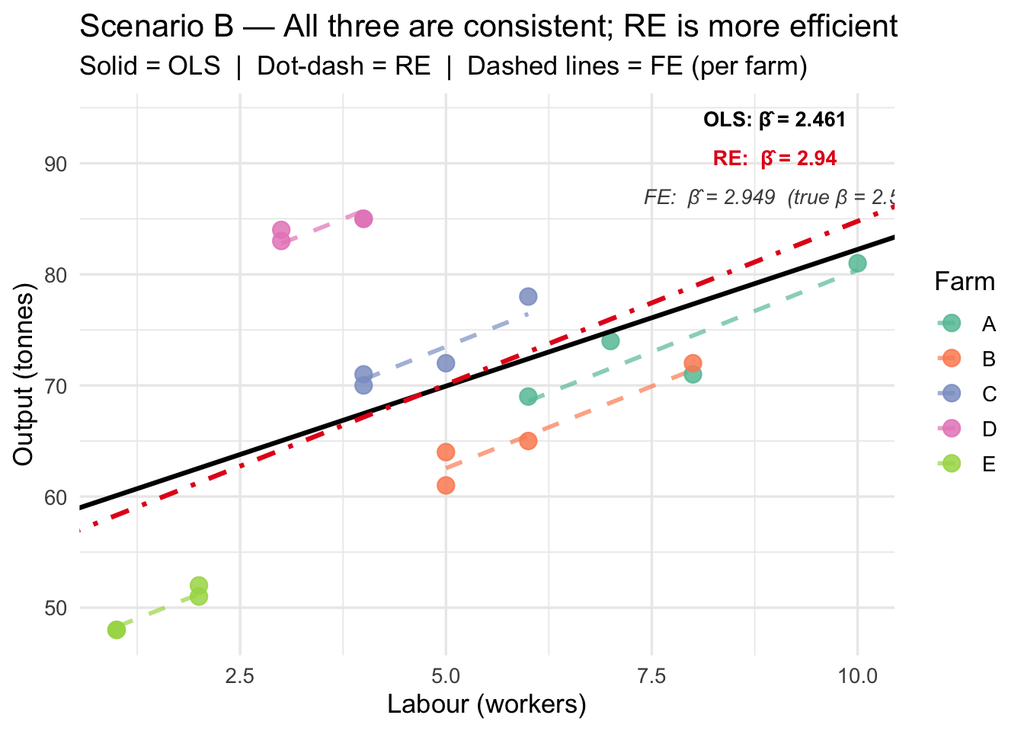

Figure 3 — Scenario B: all estimators are consistent when Cov(αᵢ, xᵢₜ) = 0

```r
df_panel_b2 <- df_panel_b |>
  group_by(Farm) |>
  mutate(Farm_mean_L = mean(Labour), Farm_mean_O = mean(Output)) |>
  ungroup()

ggplot(df_panel_b2, aes(x = Labour, y = Output, colour = Farm, group = Farm)) +
  geom_line(aes(y = Farm_mean_O + beta_fe_b * (Labour - Farm_mean_L)),
            linewidth = 1, linetype = "dashed", alpha = 0.7) +
  geom_point(size = 3.5, alpha = 0.85) +
  geom_abline(intercept = coef(mod_ols_b)[1], slope = beta_ols_b,
              colour = "black", linewidth = 1.1) +
  geom_abline(intercept = coef(mod_re_b)[1], slope = beta_re_b,
              colour = "#E41A1C", linewidth = 1.1, linetype = "dotdash") +
  scale_colour_brewer(palette = "Set2") +
  annotate("text", x = 9, y = 94,
           label = paste0("OLS: β̂ = ", beta_ols_b),
           colour = "black", fontface = "bold", size = 3.6) +
  annotate("text", x = 9, y = 90.5,
           label = paste0("RE:  β̂ = ", beta_re_b),
           colour = "#E41A1C", fontface = "bold", size = 3.6) +
  annotate("text", x = 9, y = 87,
           label = paste0("FE:  β̂ = ", beta_fe_b,
                          "  (true β = ", true_beta, ")"),
           colour = "grey30", fontface = "italic", size = 3.6) +
  labs(x = "Labour (workers)", y = "Output (tonnes)",
       title = "Scenario B — All three are consistent; RE is more efficient",
       subtitle = "Solid = OLS  |  Dot-dash = RE  |  Dashed lines = FE (per farm)",
       colour = "Farm") +
  theme_minimal(base_size = 13)
```

**TipWhat changed?**

When $\text{Cov}(\alpha_i, x_{it}) \approx 0$:

- **OLS** is now consistent (no omitted-variable bias) but ignores the error correlation structure — inefficient.
- **FE** is consistent but still discards between-farm information — less precise.
- **RE** is consistent *and* more efficient because it exploits both within and between variation, weighted optimally by the GLS transformation.

> *When the RE assumption holds, RE is the preferred estimator — unbiased and more precise than FE.*

## Step 5 — The Unique Advantage: Time-Invariant Predictors

One practical reason to prefer RE over FE: **FE cannot estimate the effect of any variable that does not change within a unit over time**.

Suppose the Ministry also collected data on each farm’s **ownership type** — whether the farm is family-owned (`0`) or a cooperative (`1`). This is fixed across the four years.

**Add time-invariant ownership variable**

```r
# Farms A, C, E are family-owned; B and D are cooperatives
ownership <- c(0, 1, 0, 1, 0)
names(ownership) <- farms

df_panel_b <- df_panel_b |>
  mutate(Ownership = ownership[Farm])

pdata_b_own <- pdata.frame(df_panel_b, index = c("Farm", "Year"))

# FE: ownership is collinear with farm dummies — dropped
mod_fe_own <- plm(Output ~ Labour + Ownership,
                  data = pdata_b_own, model = "within")

# RE: can estimate ownership effect
mod_re_own <- plm(Output ~ Labour + Ownership,
                  data = pdata_b_own, model = "random")
```

**Display coefficient tables**

```r
tibble(
  Parameter     = c("Labour (β₁)", "Ownership — cooperative (β₂)"),
  `FE estimate` = c(round(coef(mod_fe_own)["Labour"], 3),
                    "— (absorbed by farm FE)"),
  `RE estimate` = c(round(coef(mod_re_own)["Labour"],    3),
                    round(coef(mod_re_own)["Ownership"],  3))
) |>
  kable(align = "lcc",
        caption = "Table 4 — FE cannot identify time-invariant predictors; RE can")
```

Table 4 — FE cannot identify time-invariant predictors; RE can

| Parameter | FE estimate | RE estimate |
| --- | --- | --- |
| Labour (β₁) | 2.949 | 2.941 |
| Ownership — cooperative (β₂) | — (absorbed by farm FE) | 9.213 |

**NoteWhy FE cannot estimate time-invariant variables**

Fixed effects can be estimated in several ways — including the within-estimator (demeaning), first-differencing, or explicitly including unit dummy variables — but they all produce the same fundamental result: only *within-unit* variation is used for identification.

The most common approach, within-demeaning, subtracts each unit’s time-mean from every observation:

$$\tilde{y}_{it} = y_{it} - \bar{y}_i, \quad \tilde{x}_{it} = x_{it} - \bar{x}_i$$

A time-invariant variable like ownership has $x_{it} = x_i$ for all $t$, so after demeaning: $\tilde{x}_{it} = x_i - x_i = 0$. The variable is literally zeroed out — it provides no variation to estimate from. The same logic applies regardless of which estimation approach is used: if a variable never changes within a unit, no within-unit estimator can identify its effect.

RE applies only a *partial* transformation using the estimated intra-class correlation, leaving some between-unit signal intact. That between-unit signal identifies $\beta_2$.

> *This is a key practical reason RE is preferred in research designs that include important time-invariant covariates (e.g., country-level institutions, individual characteristics such as gender or ethnicity, historical conditions).*

## Step 6 — The Hausman Test: Choosing Between FE and RE

If you are uncertain whether $\text{Cov}(\alpha_i, x_{it}) = 0$, the **Hausman test** gives a formal answer.

**Logic:**

- Under $H_0$: RE assumption holds → both FE and RE are consistent, but RE is more efficient.
- Under $H_1$: RE assumption fails → FE is consistent; RE is biased.

The test statistic compares the FE and RE coefficient vectors. A large difference (relative to the sampling variance) rejects $H_0$ and points to FE.

$$H = (\hat\beta_{\text{FE}} - \hat\beta_{\text{RE}})^\top \left[\text{Var}(\hat\beta_{\text{FE}}) - \text{Var}(\hat\beta_{\text{RE}})\right]^{-1} (\hat\beta_{\text{FE}} - \hat\beta_{\text{RE}}) \sim \chi^2(k)$$

**Run Hausman test for both scenarios**

```r
ht_a <- phtest(mod_fe_a, mod_re_a)   # Scenario A: expect rejection
ht_b <- phtest(mod_fe_b, mod_re_b)   # Scenario B: expect no rejection
```

**Display Hausman test results**

```r
tibble(
  Scenario       = c("A — Cov(αᵢ, xᵢₜ) ≠ 0\n(quality correlated with labour)",
                     "B — Cov(αᵢ, xᵢₜ) ≈ 0\n(randomised labour assignment)"),
  `χ² statistic` = c(round(ht_a$statistic, 3), round(ht_b$statistic, 3)),
  df             = c(ht_a$parameter,            ht_b$parameter),
  `p-value`      = c(round(ht_a$p.value, 4),    round(ht_b$p.value, 4)),
  Decision       = c("Reject H₀ → use FE",
                     "Fail to reject H₀ → RE preferred")
) |>
  kable(align = "lcccc",
        caption = "Table 5 — Hausman test results for both scenarios")
```

Table 5 — Hausman test results for both scenarios

| Scenario | χ² statistic | df | p-value | Decision |
| --- | --- | --- | --- | --- |
| A — Cov(αᵢ, xᵢₜ) ≠ 0 |  |  |  |  |
| (quality correlated with labour) | 8.137 | 1 | 0.0043 | Reject H₀ → use FE |
| B — Cov(αᵢ, xᵢₜ) ≈ 0 |  |  |  |  |
| (randomised labour assignment) | 0.010 | 1 | 0.9202 | Fail to reject H₀ → RE preferred |

**WarningInterpreting the Hausman test carefully**

The Hausman test has real limitations in practice:

1. **Low power in short panels.** With few time periods or few units, the test may fail to detect genuine correlation. A non-rejection does not guarantee RE is safe.
2. **It only tests one direction.** The test checks whether RE is *as consistent as* FE. But if FE itself is the wrong model (e.g., non-linear effects, wrong functional form), the test can give misleading guidance.
3. **Practical knowledge matters.** If your theory or prior work strongly suggests that unobserved heterogeneity correlates with your predictor, prefer FE regardless of the test result.

> *Use the Hausman test as one input, not the final word.*

## Step 7 — Side-by-Side: All Estimators Compared

**Dot plot comparing all estimates**

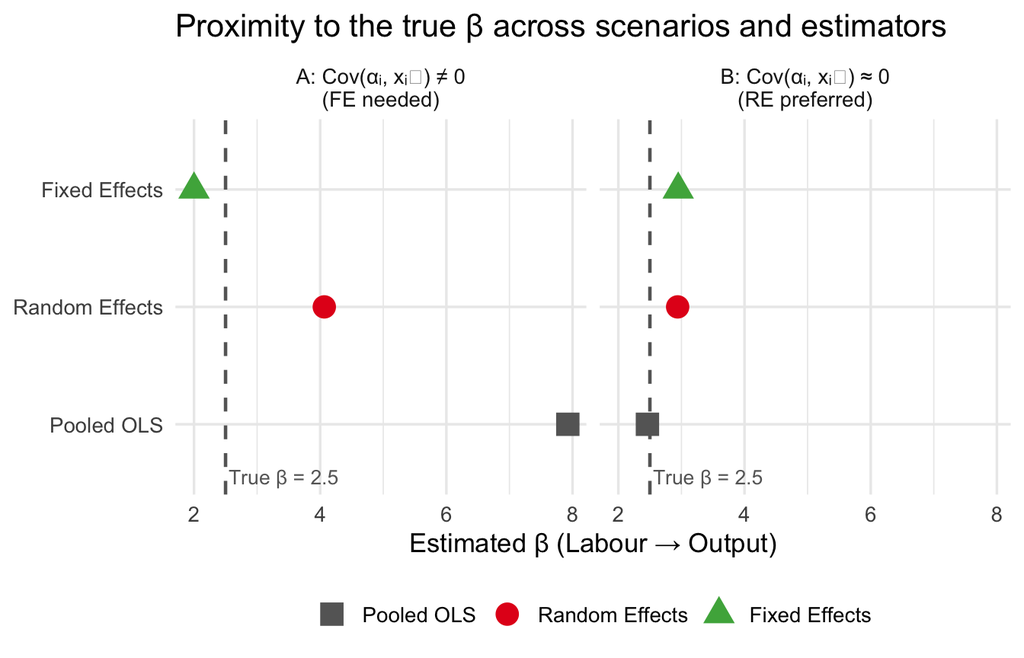

Figure 4 — Estimates from all three models across both scenarios

```r
estimates_long <- tibble(
  Estimator = rep(c("Pooled OLS", "Fixed Effects", "Random Effects"), 2),
  Scenario  = rep(c("A: Cov(αᵢ, xᵢₜ) ≠ 0\n(FE needed)",
                    "B: Cov(αᵢ, xᵢₜ) ≈ 0\n(RE preferred)"), each = 3),
  Beta      = c(beta_ols_a, beta_fe_a, beta_re_a,
                beta_ols_b, beta_fe_b, beta_re_b)
) |>
  mutate(
    Estimator = factor(Estimator,
                       levels = c("Pooled OLS", "Random Effects", "Fixed Effects"))
  )

ggplot(estimates_long,
       aes(x = Beta, y = Estimator, colour = Estimator, shape = Estimator)) +
  geom_vline(xintercept = true_beta, linetype = "dashed",
             colour = "grey40", linewidth = 0.8) +
  geom_point(size = 5) +
  annotate("text", x = true_beta + 0.05, y = 0.55,
           label = paste0("True β = ", true_beta),
           colour = "grey40", size = 3.5, hjust = 0) +
  scale_colour_manual(values = c("Pooled OLS"    = "#666666",
                                 "Fixed Effects"  = "#4DAF4A",
                                 "Random Effects" = "#E41A1C")) +
  scale_shape_manual(values  = c("Pooled OLS"    = 15,
                                 "Fixed Effects"  = 17,
                                 "Random Effects" = 16)) +
  facet_wrap(~ Scenario, ncol = 2) +
  labs(x = "Estimated β (Labour → Output)", y = NULL,
       title = "Proximity to the true β across scenarios and estimators") +
  theme_minimal(base_size = 13) +
  theme(legend.position = "bottom", legend.title = element_blank())
```

**Full comparison table**

```r
tibble(
  Estimator = c("Pooled OLS", "Fixed Effects (within)", "Random Effects (GLS)"),
  `Sc A β̂`  = c(beta_ols_a, beta_fe_a, beta_re_a),
  `Sc A Bias`= c(round(beta_ols_a - true_beta, 2),
                 round(beta_fe_a  - true_beta, 2),
                 round(beta_re_a  - true_beta, 2)),
  `Sc B β̂`  = c(beta_ols_b, beta_fe_b, beta_re_b),
  `Sc B Bias`= c(round(beta_ols_b - true_beta, 2),
                 round(beta_fe_b  - true_beta, 2),
                 round(beta_re_b  - true_beta, 2))
) |>
  kable(align = "lcccc",
        col.names = c("Estimator",
                      "Sc A: β̂", "Sc A: Bias",
                      "Sc B: β̂", "Sc B: Bias"),
        caption = paste0("Table 6 — All estimators: true β = ", true_beta))
```

Table 6 — All estimators: true β = 2.5

| Estimator | Sc A: β̂ | Sc A: Bias | Sc B: β̂ | Sc B: Bias |
| --- | --- | --- | --- | --- |
| Pooled OLS | 7.925 | 5.42 | 2.461 | -0.04 |
| Fixed Effects (within) | 2.000 | -0.50 | 2.949 | 0.45 |
| Random Effects (GLS) | 4.065 | 1.57 | 2.940 | 0.44 |

**TipReading Figure 4**

- **Left panel (Scenario A):** Only FE (green triangle) lands near the dashed line. OLS and RE are biased upward because they absorb between-farm variation contaminated by soil quality.
- **Right panel (Scenario B):** All three are close to the true $\beta$. RE (red circle) and FE are both consistent; RE’s advantage here is efficiency (smaller standard errors), not bias correction. OLS is also close because randomisation removed the confounding.

## Step 8 — Decision Framework

Use the table below as a starting point when choosing between FE and RE in practice.

| Question | FE | RE |
| --- | --- | --- |
| Is $\text{Cov}(\alpha_i, x_{it}) = 0$ plausible? | Not required | Required |
| Can I estimate time-invariant predictors? | No | Yes |
| Can I estimate effects of variables with little within-unit variation? | Poorly | Better |
| Is efficiency a concern (small $T$, large $N$)? | Less efficient | More efficient |
| Hausman test rejects $H_0$? | Preferred | Inconsistent |
| Research design uses random assignment? | Either works | RE preferred |
| Observational data with likely self-selection? | Preferred | Only if assumption is defensible |

**NoteA researcher’s heuristic**

> *“Start with FE. It is the conservative, credible choice. Use RE only when you have a strong theoretical or empirical reason to believe that unobserved heterogeneity is uncorrelated with your regressors — and even then, always report the Hausman test and a FE robustness check side by side.”*

## Summary

In this exercise you discovered:

1. **Fixed Effects** eliminates unobserved heterogeneity by exploiting within-unit variation over time — but at the cost of discarding between-unit information and losing all time-invariant predictors.
2. **Random Effects** treats heterogeneity as part of the error and uses GLS to efficiently combine within and between variation — but requires the strong assumption $\text{Cov}(\alpha_i, x_{it}) = 0$.
3. **The Hausman test** is the standard diagnostic for choosing between FE and RE. A significant result favours FE; a non-significant result makes RE defensible, though not guaranteed safe.
4. **When the RE assumption holds**, RE dominates: unbiased, efficient, and able to estimate time-invariant predictors that FE cannot touch.
5. **In practice**, begin with FE for credibility, and treat RE as a robustness check or primary specification only when the research design (e.g., random assignment) justifies it.

**ImportantExtension: The Mundlak Device**

A powerful synthesis due to Mundlak (1978): include the **within-unit means of all time-varying regressors** as additional controls in the RE model:

$$y_{it} = \mu + \beta\, x_{it} + \gamma\, \bar{x}_i + \alpha_i^* + u_{it}$$

This “Mundlak device” soaks up the correlation between $\alpha_i$ and $x_{it}$, making $\hat\beta$ numerically equivalent to the FE estimator — while the RE framework still allows time-invariant variables to enter through $\bar{x}_i$. It is increasingly recommended as a best-of-both-worlds specification, and provides a further diagnostic: if $\hat\gamma \neq 0$, the RE assumption was violated.